# Example 5: matching using MatchIt

We continue analyzing the lalonde data obtained from the MatchIt package. We estimate the propensity scores using the selected logstic regression model in last lecture.4 n

```r
library("MatchIt")
data("lalonde")

model <- glm(treat ~ re74 + race + married + I(re74^2) + re74:race, data = lalonde, family = "binomial")
eps <- predict(model, type = "response")
lps <- predict(model)
```

## Assess initial imbalance

```r
m.out0 <- matchit(treat ~ age + educ + race + married +
                   nodegree + re74 + re75, data = lalonde,
                 method = NULL, distance = "glm")
## distance here refer to a method to estimate the propensity score
## No matching is performed at this stage
summary(m.out0)
```

```
Call:
matchit(formula = treat ~ age + educ + race + married + nodegree +
    re74 + re75, data = lalonde, method = NULL, distance = "glm")

Summary of Balance for All Data:
           Means Treated Means Control Std. Mean Diff. Var. Ratio eCDF Mean eCDF Max
distance          0.5774        0.1822          1.7941     0.9211    0.3774   0.6444
age              25.8162       28.0303         -0.3094     0.4400    0.0813   0.1577
educ             10.3459       10.2354          0.0550     0.4959    0.0347   0.1114
raceblack         0.8432        0.2028          1.7615          .    0.6404   0.6404
racehispan        0.0595        0.1422         -0.3498          .    0.0827   0.0827
racewhite         0.0973        0.6550         -1.8819          .    0.5577   0.5577
married           0.1892        0.5128         -0.8263          .    0.3236   0.3236
nodegree          0.7081        0.5967          0.2450          .    0.1114   0.1114
re74           2095.5737     5619.2365         -0.7211     0.5181    0.2248   0.4470
re75           1532.0553     2466.4844         -0.2903     0.9563    0.1342   0.2876


Sample Sizes:
          Control Treated
All           429     185
Matched       429     185
Unmatched       0       0
Discarded       0       0
```

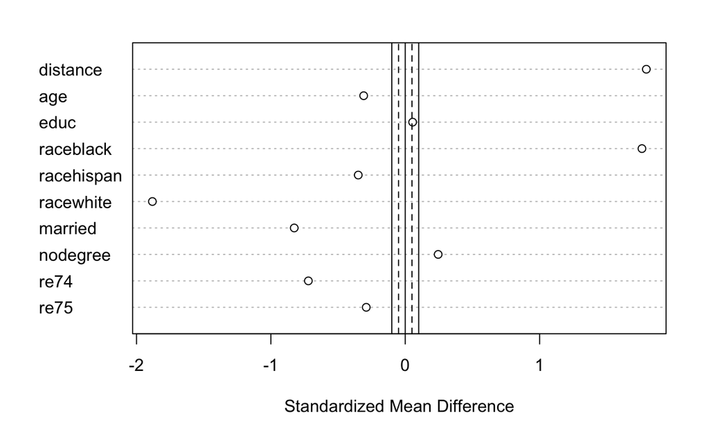

```r
## Love plot before matching
plot(summary(m.out0), abs = F)
```

```r
## Default thresholds: solid line 0.1, dashed line 0.05
```

## Drop control and treated units that are out of the estimated propenstiy score range

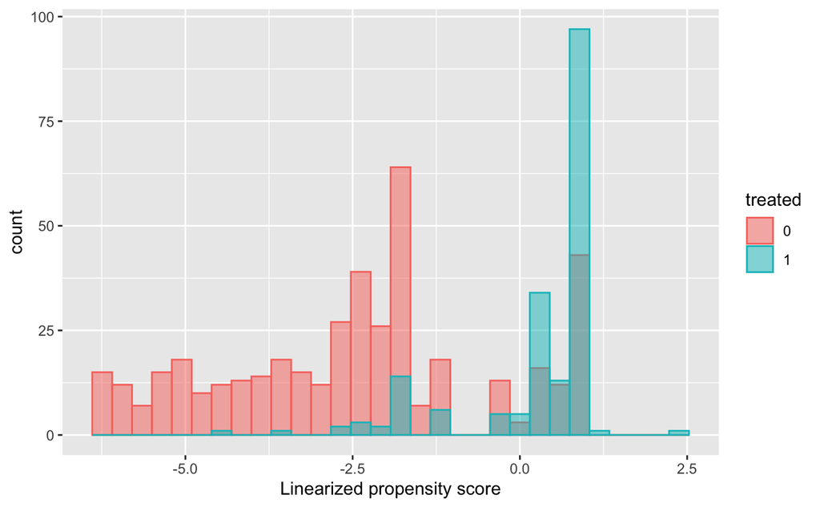

```r
library(ggplot2)
temp.data <- data.frame(lps = lps, treated = as.factor(lalonde$treat))
ggplot(temp.data, aes(x = lps, fill = treated, color = treated)) +
  geom_histogram(alpha = 0.5, position = "identity") +
  xlab("Linearized propensity score")
```

```r
idx.treated <- which((lalonde$treat == 1) & (lps > max(lps[lalonde$treat == 0])))
idx.control <- which((lalonde$treat == 0) & (lps < min(lps[lalonde$treat == 1])))
idx <- c(idx.treated, idx.control)  ## dropped two treated units and 77 control units
lalonde <- lalonde[-idx, ]
lps <- lps[-idx]
```

From the histogram, we see a potential issue here, which is that there are not enough controls that can be potentially matched with the treated units for units whose lps > 0.

## Matching

Greedy algorithm, covariate balancing is not satisfying

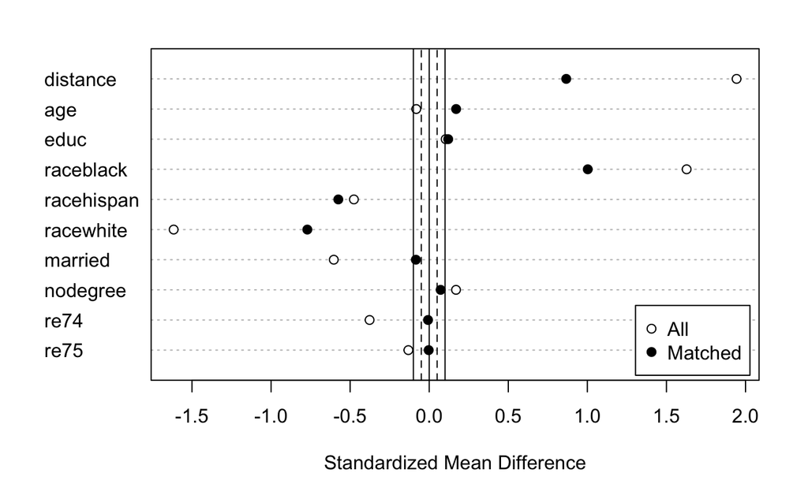

```r
## Greedy algorithm
m.out1 <- matchit(treat ~ age + educ + race + married +
                   nodegree + re74 + re75, data = lalonde,
                  estimand = "ATT",
                 method = "nearest", distance = lps)
plot(summary(m.out1), abs = F)
```

We change to optimal matching, and covariate balancing is still not satisfying

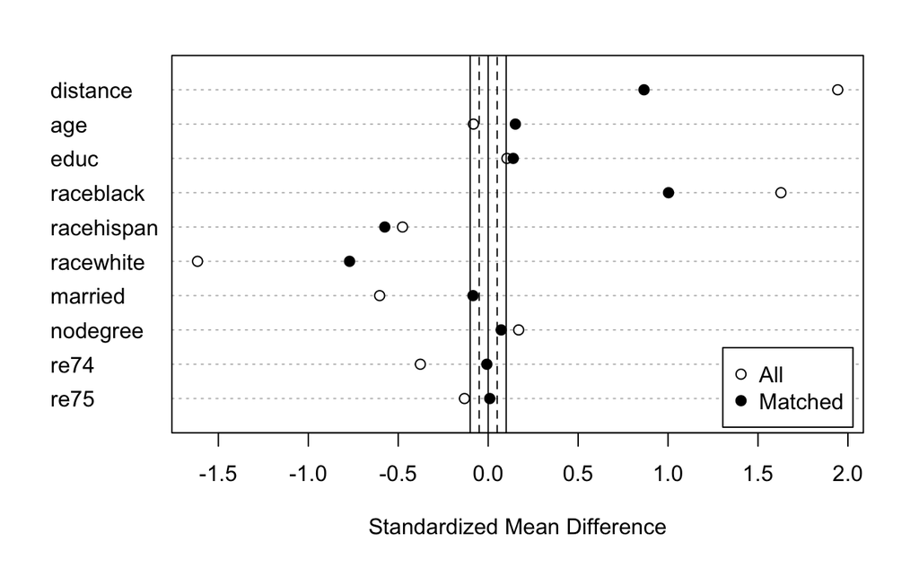

```r
## Optimal matching algorithm
## install additional package
##install.packages("optmatch") and choose the binary version
library("optmatch")
m.out2 <- matchit(treat ~ age + educ + race + married +
                   nodegree + re74 + re75, data = lalonde,
                  estimand = "ATT",
                 method = "optimal", distance = lps)
plot(summary(m.out2), abs = F)
```

You see that even the linearized propensity score are not matched well, which indicates that some treated units are not able to be well matched (as there are not enough controls with lps > 0).

Three strategies to improve balancing:

```r
## Strategy I: require exact match for race, as race seems to be the most unbalanced covariate and is discrete
m.out3 <- matchit(treat ~ age + educ + race + married +
                   nodegree + re74 + re75, data = lalonde,
                  estimand = "ATT", exact = "race",
                 method = "optimal", distance = lps)
```

```
Fewer control units than treated units in some 'exact' strata; not all treated units will get a match.
```

```r
summary(m.out3)
```

```
Call:
matchit(formula = treat ~ age + educ + race + married + nodegree +
    re74 + re75, data = lalonde, method = "optimal", distance = lps,
    estimand = "ATT", exact = "race")

Summary of Balance for All Data:
           Means Treated Means Control Std. Mean Diff. Var. Ratio eCDF Mean eCDF Max
distance          0.2259       -1.8038          1.9434     0.4496    0.3409   0.6040
age              25.8197       26.4091         -0.0819     0.4847    0.0685   0.1514
educ             10.3279       10.1193          0.1041     0.4802    0.0372   0.1027
raceblack         0.8415        0.2472          1.6276          .    0.5944   0.5944
racehispan        0.0601        0.1733         -0.4762          .    0.1132   0.1132
racewhite         0.0984        0.5795         -1.6158          .    0.4812   0.4812
married           0.1858        0.4205         -0.6033          .    0.2347   0.2347
nodegree          0.7104        0.6335          0.1694          .    0.0769   0.0769
re74           1785.3081     3243.4437         -0.3770     0.7722    0.1575   0.3977
re75           1448.6596     1860.5826         -0.1318     1.3614    0.0915   0.2458


Summary of Balance for Matched Data:
           Means Treated Means Control Std. Mean Diff. Var. Ratio eCDF Mean eCDF Max
distance         -0.0701       -0.1097          0.0379     1.0038    0.0095   0.0948
age              26.1207       26.2241         -0.0144     0.4638    0.0810   0.1983
educ             10.3793       10.0259          0.1764     0.3449    0.0513   0.1466
raceblack         0.7500        0.7500          0.0000          .    0.0000   0.0000
racehispan        0.0948        0.0948          0.0000          .    0.0000   0.0000
racewhite         0.1552        0.1552          0.0000          .    0.0000   0.0000
married           0.2328        0.2931         -0.1552          .    0.0603   0.0603
nodegree          0.7155        0.6379          0.1711          .    0.0776   0.0776
re74           2261.7502     2786.3308         -0.1356     0.6877    0.0323   0.1293
re75           2073.3520     1608.2498          0.1488     1.4552    0.0724   0.1552
           Std. Pair Dist.
distance            0.0442
age                 1.1792
educ                1.3814
raceblack           0.0000
racehispan          0.0000
racewhite           0.0000
married             0.1995
nodegree            0.9313
re74                0.5261
re75                0.6351

Percent Balance Improvement:
           Std. Mean Diff. Var. Ratio eCDF Mean eCDF Max
distance              98.1       99.5      97.2     84.3
age                   82.4       -6.1     -18.3    -31.0
educ                 -69.5      -45.1     -37.7    -42.7
raceblack            100.0          .     100.0    100.0
racehispan           100.0          .     100.0    100.0
racewhite            100.0          .     100.0    100.0
married               74.3          .      74.3     74.3
nodegree              -0.9          .      -0.9     -0.9
re74                  64.0      -44.9      79.5     67.5
re75                 -12.9      -21.6      20.8     36.9

Sample Sizes:
          Control Treated
All           352     183
Matched       116     116
Unmatched     236      67
Discarded       0       0
```

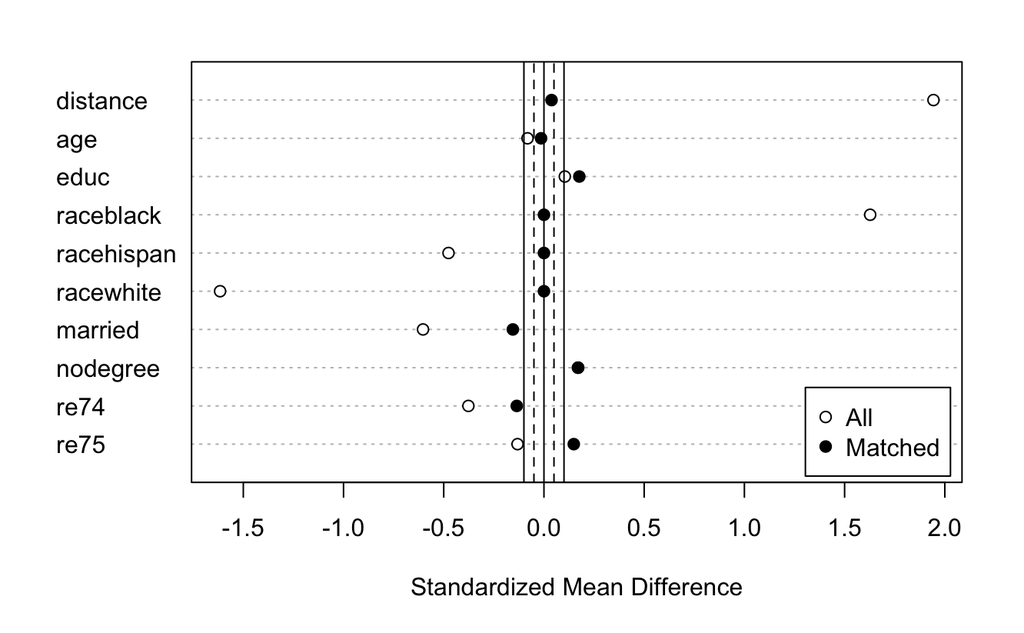

```r
plot(summary(m.out3), abs = F)
```

Strategy II: we can to improve balancing by discard units if the distance between pairs are two large

```r
head(m.out2$match.matrix)
```

```
     [,1]
NSW1 "PSID429"
NSW2 "PSID170"
NSW3 "PSID370"
NSW4 "PSID140"
NSW5 "PSID159"
NSW6 "PSID281"
```

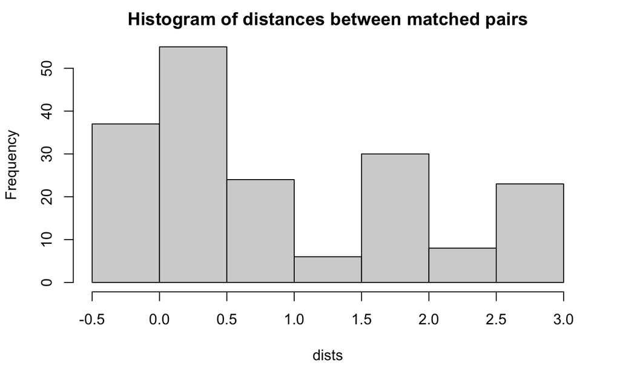

```r
names(lps) <- rownames(lalonde)
dists <- lps[rownames(m.out2$match.matrix)] - lps[m.out2$match.matrix[,1]]
hist(dists, main = "Histogram of distances between matched pairs")
```

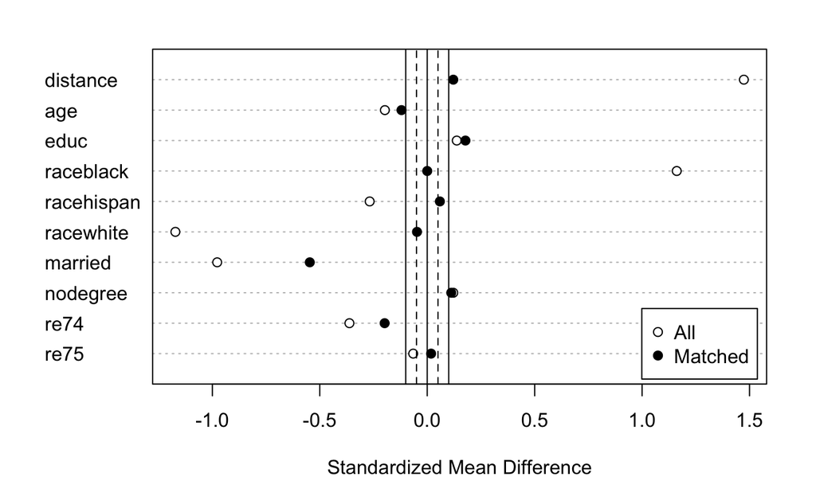

```r
## We see that some distances are large.

## We set a threshold 1 to make a balance between removing poor matches and retain most of the treated units
ID.treated.notmatched <- names(dists[abs(dists) > 1])
lalonde.new <- lalonde[!(rownames(lalonde) %in% ID.treated.notmatched),]
lps.new <- lps[!(rownames(lalonde) %in% ID.treated.notmatched)]

m.out4 <- matchit(treat ~ age + educ + race + married +
                   nodegree + re74 + re75, data = lalonde.new,
                  estimand = "ATT",
                 method = "optimal", distance = lps.new)
plot(summary(m.out4), abs = F)
```

```r
summary(m.out4)
```

```
Call:
matchit(formula = treat ~ age + educ + race + married + nodegree +
    re74 + re75, data = lalonde.new, method = "optimal", distance = lps.new,
    estimand = "ATT")

Summary of Balance for All Data:
           Means Treated Means Control Std. Mean Diff. Var. Ratio eCDF Mean eCDF Max
distance          0.0425       -1.8038          1.4736     0.6469    0.3145   0.5148
age              25.1034       26.4091         -0.1971     0.4108    0.0724   0.1295
educ             10.3793       10.1193          0.1375     0.4280    0.0401   0.0988
raceblack         0.7500        0.2472          1.1613          .    0.5028   0.5028
racehispan        0.0948        0.1733         -0.2678          .    0.0785   0.0785
racewhite         0.1552        0.5795         -1.1721          .    0.4244   0.4244
married           0.1121        0.4205         -0.9776          .    0.3084   0.3084
nodegree          0.6897        0.6335          0.1213          .    0.0561   0.0561
re74           1793.4120     3243.4437         -0.3621     0.8277    0.1699   0.4146
re75           1623.3948     1860.5826         -0.0653     1.8385    0.0938   0.2685


Summary of Balance for Matched Data:
           Means Treated Means Control Std. Mean Diff. Var. Ratio eCDF Mean eCDF Max
distance          0.0425       -0.1095          0.1213     1.0880    0.0364   0.2931
age              25.1034       25.8966         -0.1197     0.3837    0.0884   0.2069
educ             10.3793       10.0431          0.1778     0.3657    0.0467   0.0948
raceblack         0.7500        0.7500          0.0000          .    0.0000   0.0000
racehispan        0.0948        0.0776          0.0588          .    0.0172   0.0172
racewhite         0.1552        0.1724         -0.0476          .    0.0172   0.0172
married           0.1121        0.2845         -0.5466          .    0.1724   0.1724
nodegree          0.6897        0.6379          0.1118          .    0.0517   0.0517
re74           1793.4120     2587.1274         -0.1982     0.7040    0.0779   0.2414
re75           1623.3948     1557.9356          0.0180     1.4168    0.0220   0.0776
           Std. Pair Dist.
distance            0.1218
age                 1.5072
educ                1.3538
raceblack           0.0000
racehispan          0.0588
racewhite           0.0476
married             0.6012
nodegree            0.9317
re74                0.5919
re75                0.5909

Percent Balance Improvement:
           Std. Mean Diff. Var. Ratio eCDF Mean eCDF Max
distance              91.8       80.6      88.4     43.1
age                   39.3       -7.7     -22.0    -59.8
educ                 -29.3      -18.6     -16.5      4.1
raceblack            100.0          .     100.0    100.0
racehispan            78.0          .      78.0     78.0
racewhite             95.9          .      95.9     95.9
married               44.1          .      44.1     44.1
nodegree               7.9          .       7.9      7.9
re74                  45.3      -85.7      54.1     41.8
re75                  72.4       42.8      76.6     71.1

Sample Sizes:
          Control Treated
All           352     116
Matched       116     116
Unmatched     236       0
Discarded       0       0
```

Covariate balancing improves. However, notice that because we have removed more than 1/3 of of the treated units, the treated population may have changed dramastically. The ATT we estimate here can be biased for the ATT of the original population.

Strategy III: In the software tutorial, it uses another method called “optimal full matching” and reaches extremely good balancing. It assigns every treated and control unit in the sample to one subclass each (Hansen 2004; Stuart and Green 2008). Each subclass contains one treated unit and one or more control units or one control units and one or more treated units. Here it performs better than optimal matching, as full matching allows one control be matched with many treated units.

We can also use matching with replacement here, which does a similar job.

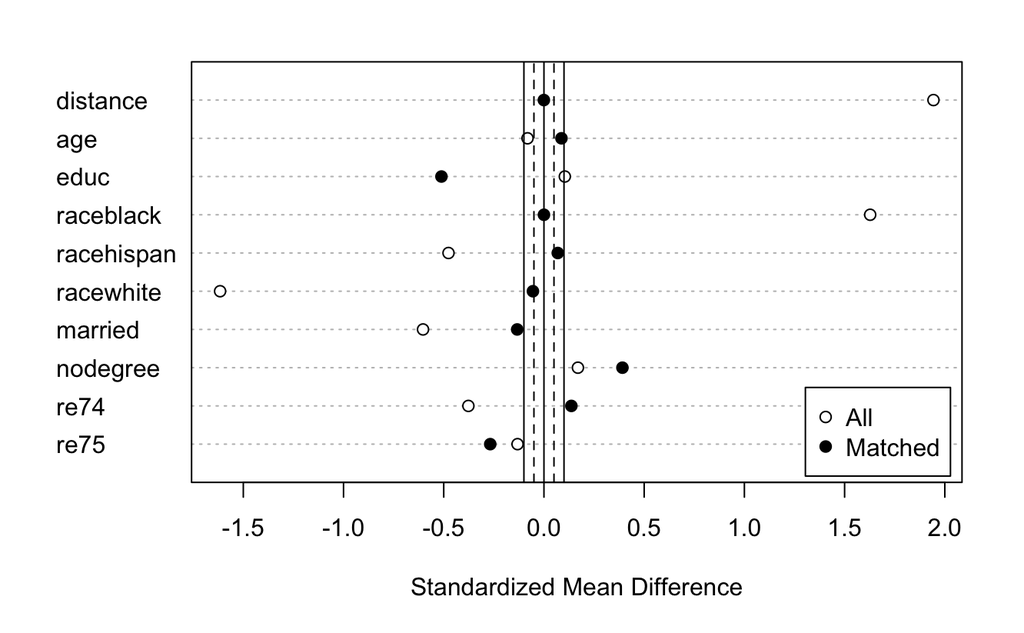

```r
## We match each treated with 2 controls to increase stability (as some controls may be used multiple times)
m.out5 <- matchit(treat ~ age + educ + race + married +
                   nodegree + re74 + re75, data = lalonde,
                  estimand = "ATT", replace= T, ratio = 2,
                 method = "nearest", distance = lps)
plot(summary(m.out5), abs = F)
```

Actually, for matching with replacement you can change the propensity score estimation method to the simple logistic regression using all covariates as linear terms, and you will see an even better covariate balancing result.

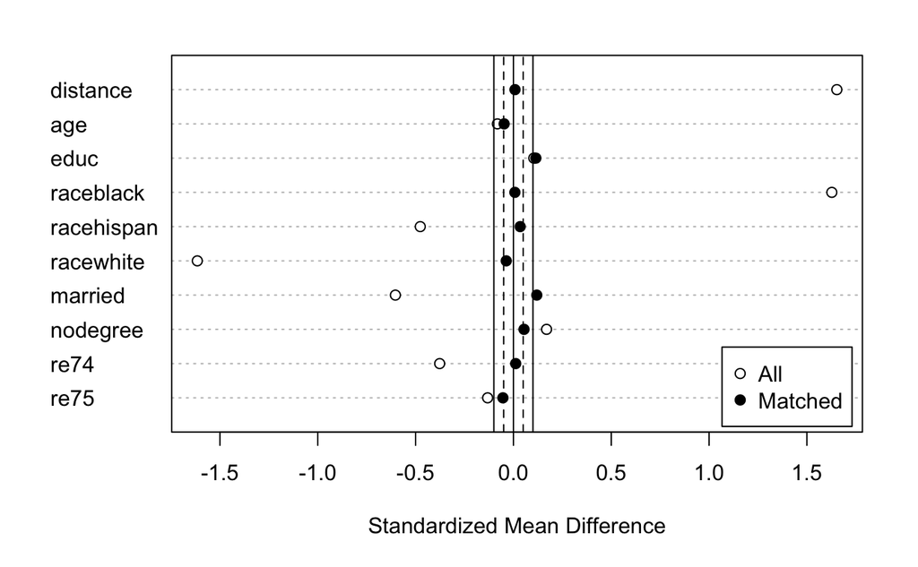

```r
m.out6 <- matchit(treat ~ age + educ + race + married +
                   nodegree + re74 + re75, data = lalonde,
                  estimand = "ATT", replace= T, ratio = 2,
                 method = "nearest", distance = "glm")
plot(summary(m.out6), abs = F)
```

## estimate the ATT

We can continue with either m.out3 or m.out6.

- If we continue with m.out3:

```r
m.data <- match.data(m.out3)
head(m.data)
```

|  | treat | age | educ | race | married | nodegree | re74 | re75 | re78 | distance | weights | subclass |
| --- | --- | --- | --- | --- | --- | --- | --- | --- | --- | --- | --- | --- |
| NSW2 | 1 | 22 | 9 | hispan | 0 | 1 | 0 | 0 | 3595.894 | -1.1655644 | 1 | 104 |
| NSW3 | 1 | 30 | 12 | black | 0 | 0 | 0 | 0 | 24909.450 | 0.8682795 | 1 | 59 |
| NSW10 | 1 | 33 | 12 | white | 1 | 0 | 0 | 0 | 12418.070 | -2.4183637 | 1 | 3 |
| NSW18 | 1 | 23 | 10 | black | 0 | 1 | 0 | 0 | 7693.400 | 0.8682795 | 1 | 36 |
| NSW19 | 1 | 40 | 12 | black | 0 | 0 | 0 | 0 | 10804.320 | 0.8682795 | 1 | 74 |
| NSW20 | 1 | 26 | 12 | black | 0 | 0 | 0 | 0 | 10747.350 | 0.8682795 | 1 | 110 |

```r
## Neyman's approach, treating the data as from a pairwise randomized experiment
tau_hat_vec <- sapply(levels(m.data$subclass), function(sc) {
  treated <- m.data$re78[m.data$subclass == sc & m.data$treat == 1]
  control <- m.data$re78[m.data$subclass == sc & m.data$treat == 0]
  return(treated - control)
})

tau_hat <- mean(tau_hat_vec, na.rm = T)
sd_tau_hat <- sd(tau_hat_vec)/sqrt(length(tau_hat_vec))
print(c(tau_hat, sd_tau_hat))
```

```
[1] 1633.733 1058.917
```

```r
## 95% CI
print(c(tau_hat- 1.96 * sd_tau_hat, tau_hat + 1.96 * sd_tau_hat))
```

```
[1] -441.7443 3709.2105
```

Neyman’s approach with regression adjustment of the bias

```r
## First run a linear regression on the control (remember to remove the treatment assignment variable!)

fit0 <- lm(re78 ~ age + educ + race + married + nodegree +
             re74 + re75, data = m.data[m.data$treat == 0, ])

m.data$predicted_y0 <- predict(fit0, m.data)

## Neyman's approach with regression adjustment
tau_hat_vec_adjusted <- sapply(levels(m.data$subclass), function(sc) {
  treated <- m.data$re78[m.data$subclass == sc & m.data$treat == 1]
  control <- m.data$re78[m.data$subclass == sc & m.data$treat == 0]

  bias <- m.data$predicted_y0[m.data$subclass == sc & m.data$treat == 1] -
    m.data$predicted_y0[m.data$subclass == sc & m.data$treat == 0]
  control.adjusted <- control + bias

  return(treated - control.adjusted)
})

tau_hat_adjusted <- mean(tau_hat_vec_adjusted)
sd_tau_hat_adjusted <- sd(tau_hat_vec_adjusted)/sqrt(length(tau_hat_vec_adjusted))
print(c(tau_hat_adjusted, sd_tau_hat_adjusted))
```

```
[1] 1316.275 1039.687
```

```r
## 95% CI
print(c(tau_hat_adjusted- 1.96 * sd_tau_hat_adjusted, tau_hat_adjusted + 1.96 * sd_tau_hat_adjusted))
```

```
[1] -721.5113 3354.0616
```

Run outcome regression directly:

```r
fit <- lm(re78 ~ treat + age + educ + race + married + nodegree +
             re74 + re75, data = m.data, weights = m.data$weights)
summary(fit)
```

```
Call:
lm(formula = re78 ~ treat + age + educ + race + married + nodegree +
    re74 + re75, data = m.data, weights = m.data$weights)

Residuals:
   Min     1Q Median     3Q    Max
 -8775  -5569  -2461   3739  53111

Coefficients:
              Estimate Std. Error t value Pr(>|t|)
(Intercept) -647.84836 4259.36037  -0.152   0.8792
treat       1369.97912 1033.01727   1.326   0.1861
age           45.34815   59.45116   0.763   0.4464
educ         418.06660  281.66535   1.484   0.1392
racehispan  2955.46825 1776.60496   1.664   0.0976 .
racewhite    922.70695 1429.48384   0.645   0.5193
married      171.05278 1289.29833   0.133   0.8946
nodegree     422.36639 1490.59059   0.283   0.7772
re74          -0.05998    0.13628  -0.440   0.6603
re75           0.14356    0.18787   0.764   0.4456
---
Signif. codes:  0 ‘***’ 0.001 ‘**’ 0.01 ‘*’ 0.05 ‘.’ 0.1 ‘ ’ 1

Residual standard error: 7626 on 222 degrees of freedom
Multiple R-squared:  0.0391,    Adjusted R-squared:  0.0001402
F-statistic: 1.004 on 9 and 222 DF,  p-value: 0.438
```

Results are similar to the regression adjustment of bias.

- If we continue with m.data6

```r
m.data <- match.data(m.out6)
head(m.out6$match.matrix)
```

```
     [,1]      [,2]
NSW1 "PSID345" "PSID234"
NSW2 "PSID79"  "PSID66"
NSW3 "PSID134" "PSID173"
NSW4 "PSID412" "PSID226"
NSW5 "PSID406" "PSID401"
NSW6 "PSID416" "PSID277"
```

```r
## Neyman's approach
tau_hat_vec <- sapply(rownames(m.out6$match.matrix), function(ID) {
  treated <- m.data[ID,]$re78
  control <- m.data[m.out6$match.matrix[ID,1],]$re78
  return(treated - control)
})


tau_hat <- mean(tau_hat_vec, na.rm = T)

sd_tau_hat <- sd(tau_hat_vec)/sqrt(length(tau_hat_vec))
print(c(tau_hat, sd_tau_hat))
```

```
[1] 1504.2209  696.2598
```

```r
## 95% CI
print(c(tau_hat- 1.96 * sd_tau_hat, tau_hat + 1.96 * sd_tau_hat))
```

```
[1]  139.5517 2868.8901
```

Neyman’s approach with regression adjustment of the bias

```r
## First run a linear regression on the control (remember to remove the treatment assignment variable!)

fit0 <- lm(re78 ~ age + educ + race + married + nodegree +
             re74 + re75, data = m.data[m.data$treat == 0, ])

m.data$predicted_y0 <- predict(fit0, m.data)

## Neyman's approach with regression adjustment
tau_hat_vec_adjusted <- sapply(rownames(m.out6$match.matrix), function(ID) {
  treated <- m.data[ID,]$re78
  control <- m.data[m.out6$match.matrix[ID,1],]$re78

  bias <- m.data[ID,]$predicted_y0 -
    m.data[m.out6$match.matrix[ID,1],]$predicted_y0
  control.adjusted <- control + bias

  return(treated - control.adjusted)
})

tau_hat_adjusted <- mean(tau_hat_vec_adjusted)
sd_tau_hat_adjusted <- sd(tau_hat_vec_adjusted)/sqrt(length(tau_hat_vec_adjusted))
print(c(tau_hat_adjusted, sd_tau_hat_adjusted))
```

```
[1] 1421.1407  697.8793
```

```r
## 95% CI
print(c(tau_hat_adjusted- 1.96 * sd_tau_hat_adjusted, tau_hat_adjusted + 1.96 * sd_tau_hat_adjusted))
```

```
[1]   53.29722 2788.98425
```

Results are different because:

- m.out3 only estimate the ATT of a subset of treated units
- m.out6 may highly depend on the outcome of a few controls